# Assignment 4

## Exploratory Data Work on Bank Dataset

In this markdown document, I am going to analyze the Bank dataset and get insights about the data. The purpose of this task is to represent the data graphically.

#### 1. Distribution across Marital Status

Listed below is the distribution of people by their marital status. We can see that most of data is of married people.

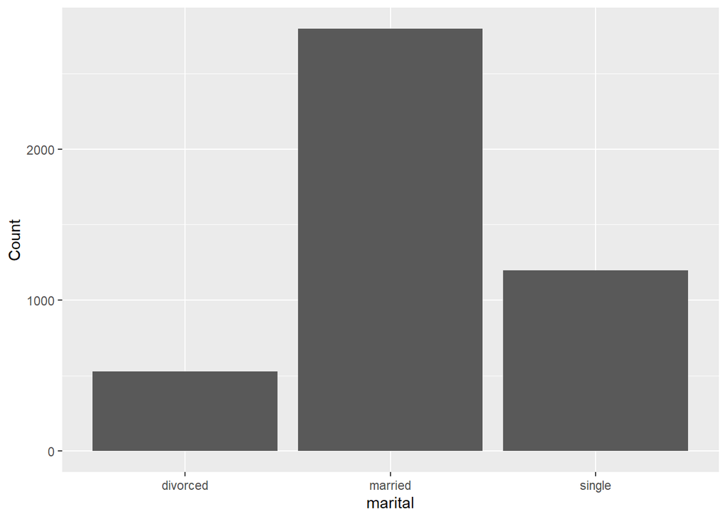

```r
b1<-bank %>%
  group_by(`marital`) %>%
  summarize(Count = n())
ggplot(b1, aes(marital,Count)) +
  geom_bar(stat='identity')
```

#### 2. Balance Distribution of Students grouped by Housing as a factor

Listed below is the balance distribution of people whose job is listed as student. They are grouped together by whether they have housing or not.We can see that among students, those without housing generally have higher balance.

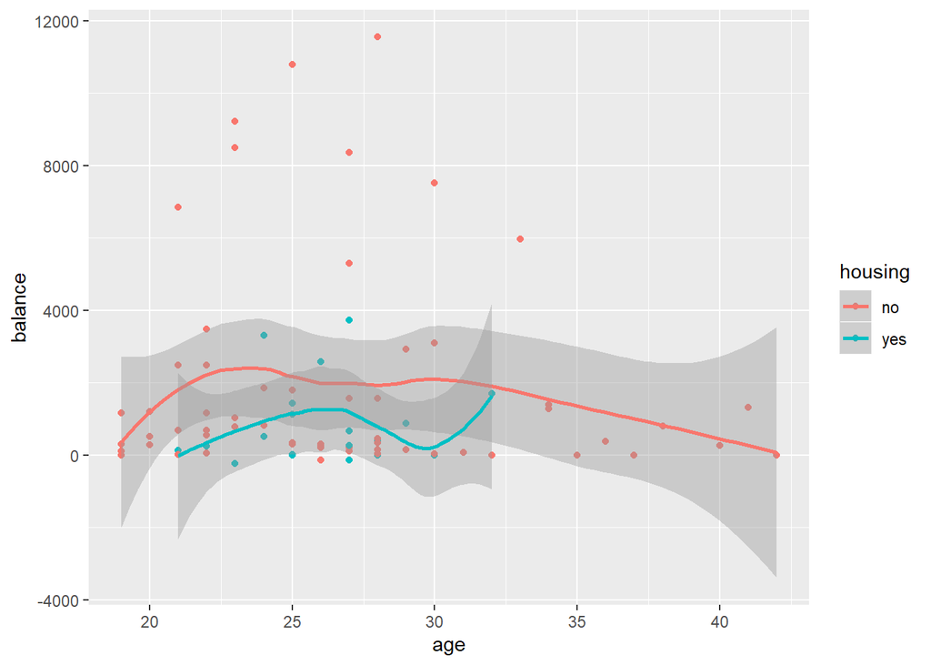

```r
#View(bank)
b2 <- bank %>%
  filter(job == "student")
ggplot(b2,aes(age,balance,color=housing)) +
  geom_point() +
  geom_smooth()
```

#### 3. Education level of Different jobs across Age

Below we can see the distribution of education level of different jobs across their age.Major inference is that most of Management has tertiary level of education and admin have secondary level.

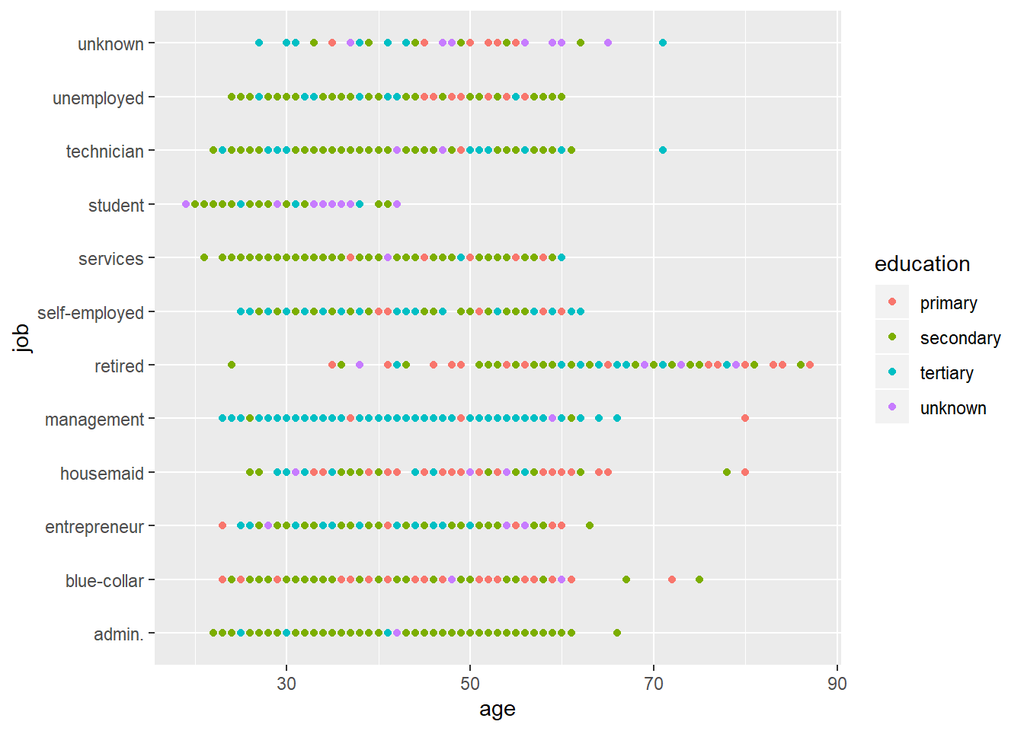

```r
ggplot(bank) +
geom_point(aes(job, age, color = education)) +
coord_flip()
```

#### 4. Age Distribution across poutcomes.

Below is the density distribution of Age for different poutcomes.We can infer that there is no special pattern of poutcomes across age and their density plots are similar.

```r
summary(bank$balance)
```

```
##    Min. 1st Qu.  Median    Mean 3rd Qu.    Max.
##   -3313      69     444    1423    1480   71188
```

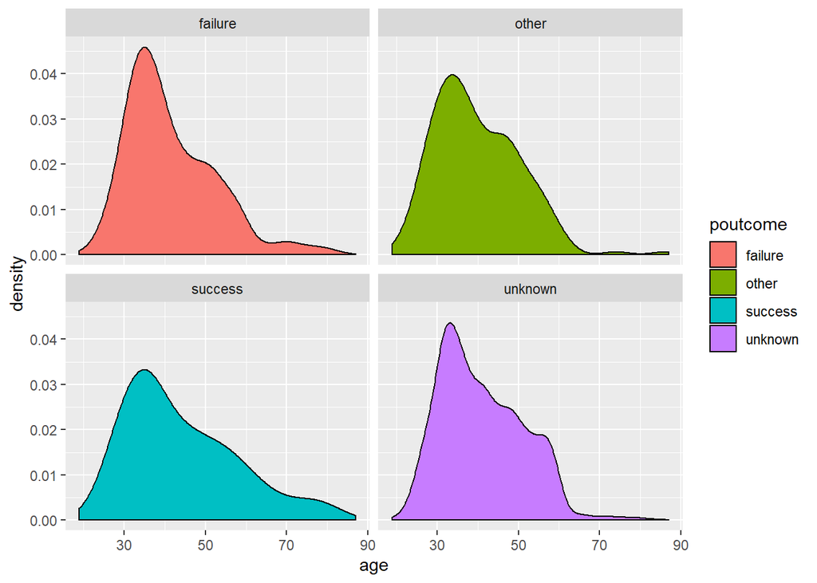

```r
ggplot(bank,aes(age,fill=poutcome)) +
geom_density() +
facet_wrap(~poutcome)
```

#### 5. Education distribution across Marital Status

Below is the number of data points of education of different marital status across various education levels. We can infer that most of data is of married people having secondary level of education.

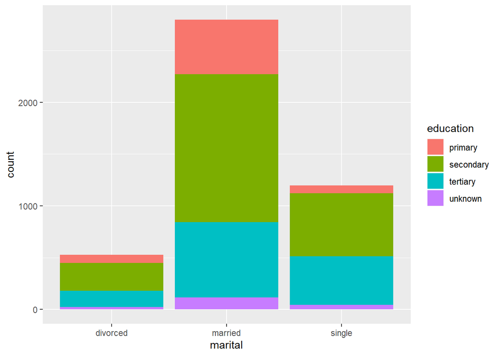

```r
ggplot(data = bank, mapping = aes(x = marital, fill = education)) +
  geom_bar()
```

#### 6. Count of Customers with unknown contact

Below is the count of customers across various jobs who have an unknown contact. We can see that blue collar are in majority for dataset where contact is unknown.

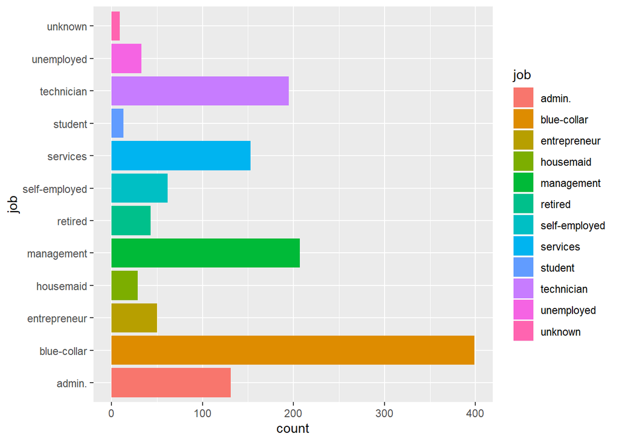

```r
bank %>%
  filter(contact=="unknown") %>%
  ggplot(mapping = aes(x = job,fill=job))+
  geom_bar()+
  coord_flip()
```

#### 7. Distribution of poutcome

Here I am finding distribution of poutcome column across different months. Here we can infer that for months from June to August, data of poutcome is mostly unknown.

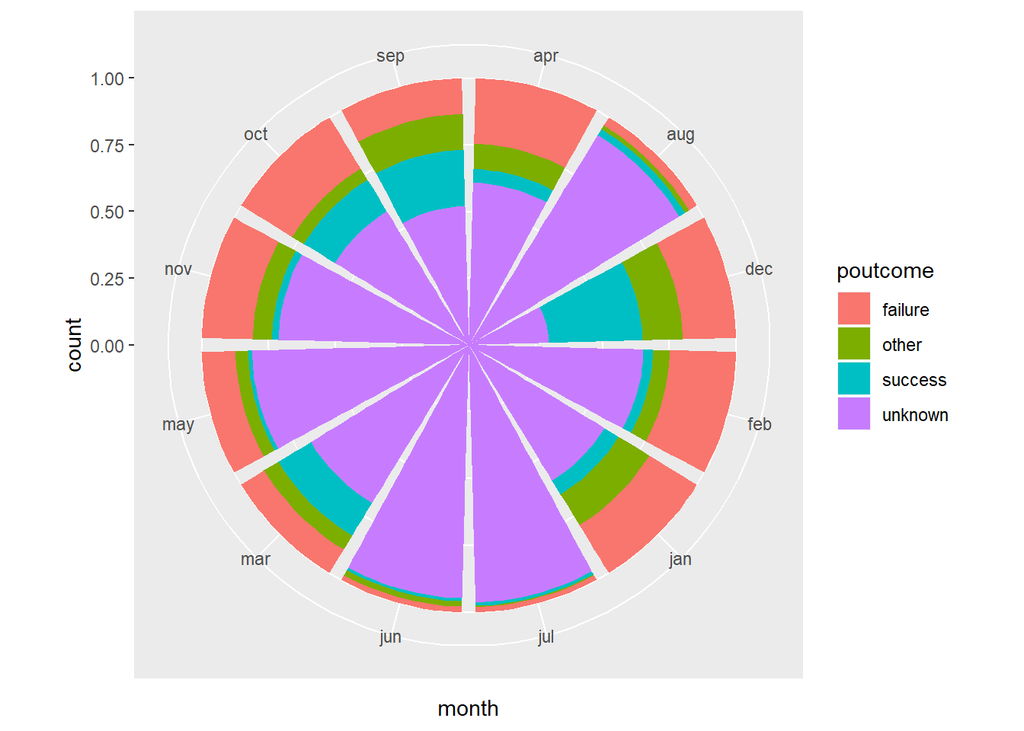

```r
ggplot(bank) + geom_bar(mapping = aes(x = month, fill = poutcome),
position = "fill") + coord_polar()
```

#### 8. Summarize balance of customers with loan=yes

Here I am finding the summary of balances of those customers whose loan=yes. Most of the balance outliers are around age 50.

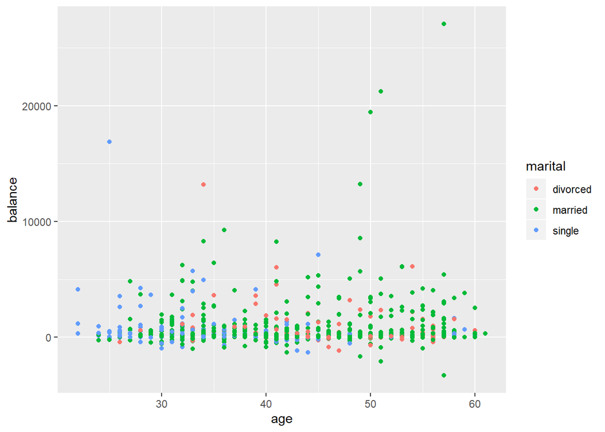

```r
bank %>%
  filter(loan=="yes")%>%
  ggplot() +
  geom_point(mapping=aes(x = age, y = balance,color=marital))
```

#### 9. Distribution of duration across contact

Here I am finding distribution of duration across contact.We can see that for senior people, contact number is generally known.

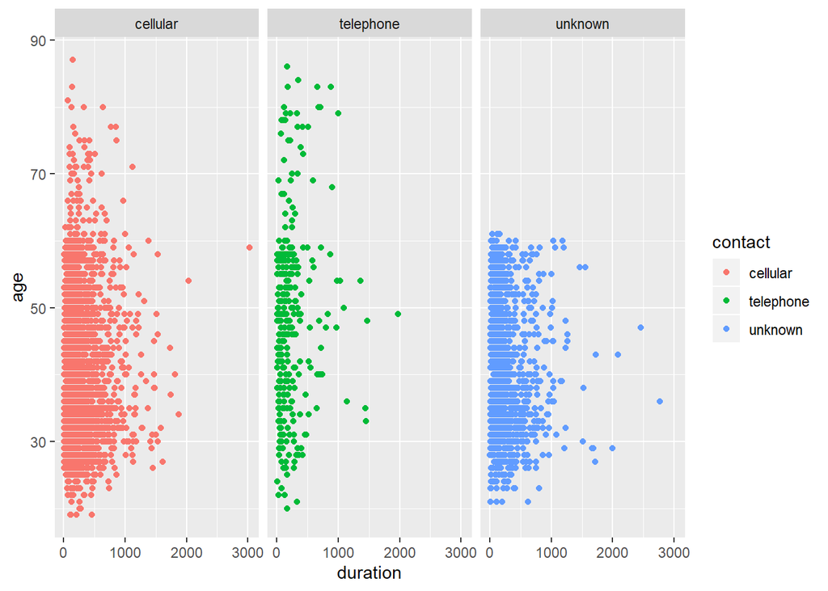

```r
ggplot(bank, aes(duration, age,color=contact)) +
  geom_point() +
  facet_wrap(. ~ contact)
```

#### 10. Distribution of marital across day

Below is the distribution of marital across different days.We can see that distribution of marital is similar across all days.

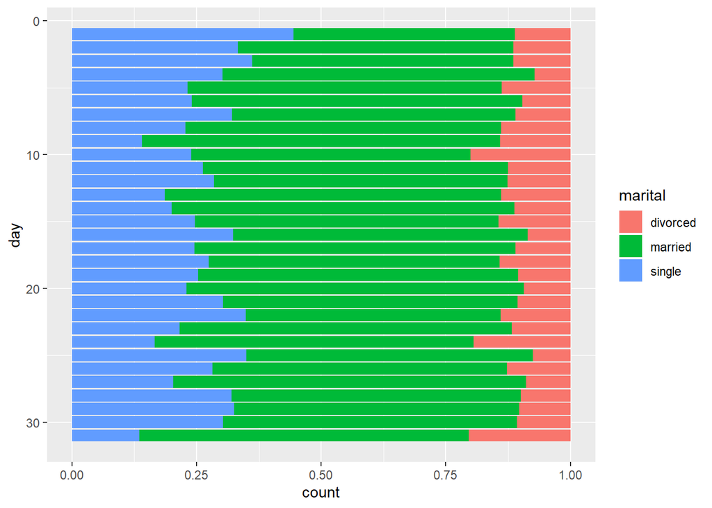

```r
ggplot(bank) +
geom_bar(mapping = aes(x = day, fill = marital), position = "fill") +
coord_flip() +
scale_x_reverse()
```